# TWS workshop: Coding Session 1

Avgar, Fieberg & Signer

September 2019

# Introduction to `amt`

```r
dat <- read_csv(here::here("data/raw/Martes pennanti LaPoint New York.csv"))
```

Check howm many individuals there are

```r
unique(dat$`individual-local-identifier`)
```

```
## [1] "F1" "F2" "F3" "M1" "M2" "M3" "M4" "M5"
```

and the number of observation for each individual.

```r
table(dat$`individual-local-identifier`)
```

```
##
##    F1    F2    F3    M1    M2    M3    M4    M5
##  2795  4689  3383  1990  3573  5013 10846 15058
```

Next, we create an `amt` track

```r
dat1 <- filter(dat, `individual-local-identifier` == "M2")
dat1 %>% make_track(`location-long`, `location-lat`)
```

```
## .t missing, creating `track_xy`.
```

```
## # A tibble: 3,573 x 2
##       x_    y_
##    <dbl> <dbl>
##  1  NA    NA
##  2 -73.9  42.8
##  3 -73.9  42.8
##  4  NA    NA
##  5 -73.9  42.8
##  6 -73.9  42.8
##  7 -73.9  42.8
##  8 -73.9  42.8
##  9 -73.9  42.8
## 10 -73.9  42.8
## # … with 3,563 more rows
```

Add a coordinate reference system (CRS)

```r
dat1 %>% make_track(`location-long`, `location-lat`, crs = CRS("+init=epsg:4326"))
```

```
## .t missing, creating `track_xy`.
```

```
## # A tibble: 3,573 x 2
##       x_    y_
##  * <dbl> <dbl>
##  1  NA    NA
##  2 -73.9  42.8
##  3 -73.9  42.8
##  4  NA    NA
##  5 -73.9  42.8
##  6 -73.9  42.8
##  7 -73.9  42.8
##  8 -73.9  42.8
##  9 -73.9  42.8
## 10 -73.9  42.8
## # … with 3,563 more rows
```

Add time

```r
dat2 <- dat1 %>% make_track(`location-long`, `location-lat`, timestamp, crs = CRS("+init=epsg:4326"))
```

```
## .t found, creating `track_xyt`.
```

```r
dat2
```

```
## # A tibble: 3,573 x 3
##       x_    y_ t_
##  * <dbl> <dbl> <dttm>
##  1  NA    NA   2011-02-10 16:50:00
##  2 -73.9  42.8 2011-02-10 16:59:31
##  3 -73.9  42.8 2011-02-10 17:00:52
##  4  NA    NA   2011-02-10 17:10:00
##  5 -73.9  42.8 2011-02-10 17:11:22
##  6 -73.9  42.8 2011-02-10 17:20:40
##  7 -73.9  42.8 2011-02-10 17:30:50
##  8 -73.9  42.8 2011-02-10 17:41:16
##  9 -73.9  42.8 2011-02-10 17:50:53
## 10 -73.9  42.8 2011-02-10 18:01:08
## # … with 3,563 more rows
```

Remove fixes with missing coordinates (do investigate where the NA’s come from)

```r
dat2 <- filter(dat2, !is.na(x_), !is.na(y_))
dat2
```

```
## # A tibble: 1,638 x 3
##       x_    y_ t_
##  * <dbl> <dbl> <dttm>
##  1 -73.9  42.8 2011-02-10 16:59:31
##  2 -73.9  42.8 2011-02-10 17:00:52
##  3 -73.9  42.8 2011-02-10 17:11:22
##  4 -73.9  42.8 2011-02-10 17:20:40
##  5 -73.9  42.8 2011-02-10 17:30:50
##  6 -73.9  42.8 2011-02-10 17:41:16
##  7 -73.9  42.8 2011-02-10 17:50:53
##  8 -73.9  42.8 2011-02-10 18:01:08
##  9 -73.9  42.8 2011-02-10 18:10:52
## 10 -73.9  42.8 2011-02-10 18:20:55
## # … with 1,628 more rows
```

Transform coordinates to a metric CRS (e.g., NAD83)

```r
dat2 <- transform_coords(dat2, CRS("+init=epsg:5070"))
dat2
```

```
## # A tibble: 1,638 x 3
##          x_       y_ t_
##  *    <dbl>    <dbl> <dttm>
##  1 1782639. 2407234. 2011-02-10 16:59:31
##  2 1782654. 2407244. 2011-02-10 17:00:52
##  3 1782637. 2407225. 2011-02-10 17:11:22
##  4 1782645. 2407223. 2011-02-10 17:20:40
##  5 1782627. 2407232. 2011-02-10 17:30:50
##  6 1782612. 2407244. 2011-02-10 17:41:16
##  7 1782634. 2407233. 2011-02-10 17:50:53
##  8 1782653. 2407269. 2011-02-10 18:01:08
##  9 1782639. 2407234. 2011-02-10 18:10:52
## 10 1782635. 2407217. 2011-02-10 18:20:55
## # … with 1,628 more rows
```

Work with `tracks`

```r
dat2 %>% step_lengths() %>% head()  # Step lengths
```

```
## [1] 17.776165 25.088881  7.446075 20.191599 19.285146 24.793985
```

```r
dat2 %>% direction_rel() %>% head()  # Relative direction
```

```
## [1]         NA -2.8335937  2.0454632  2.9047455 -0.1910427 -2.9249795
```

```r
dat2 %>% time_of_day()  # Time of day
```

```
## # A tibble: 1,638 x 4
##          x_       y_ t_                  tod_
##  *    <dbl>    <dbl> <dttm>              <chr>
##  1 1782639. 2407234. 2011-02-10 16:59:31 day
##  2 1782654. 2407244. 2011-02-10 17:00:52 day
##  3 1782637. 2407225. 2011-02-10 17:11:22 day
##  4 1782645. 2407223. 2011-02-10 17:20:40 day
##  5 1782627. 2407232. 2011-02-10 17:30:50 day
##  6 1782612. 2407244. 2011-02-10 17:41:16 day
##  7 1782634. 2407233. 2011-02-10 17:50:53 day
##  8 1782653. 2407269. 2011-02-10 18:01:08 day
##  9 1782639. 2407234. 2011-02-10 18:10:52 day
## 10 1782635. 2407217. 2011-02-10 18:20:55 day
## # … with 1,628 more rows
```

```r
dat2 %>% bbox()  # Bounding box of all relocations
```

```
## class       : SpatialPolygons
## features    : 1
## extent      : 1782612, 1789711, 2402250, 2408766  (xmin, xmax, ymin, ymax)
## crs         : +proj=aea +lat_1=29.5 +lat_2=45.5 +lat_0=23 +lon_0=-96 +x_0=0 +y_0=0 +ellps=GRS80 +towgs84=0,0,0,0,0,0,0 +units=m +no_defs
```

We can also add columns to the `data.frame` with this information

```r
dat3 <- dat2 %>% mutate(sl = step_lengths(.)) %>% time_of_day()
```

Now we may want to plot our the step length distribution for day an night

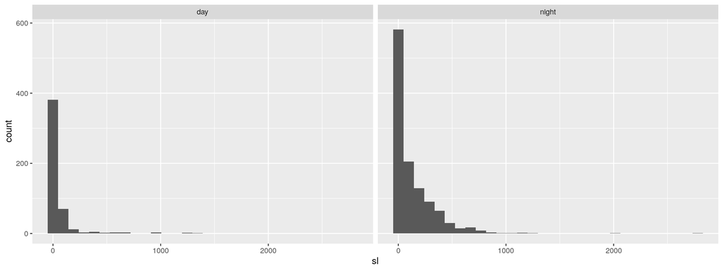

```r
dat3 %>% ggplot(aes(x = sl)) +  geom_histogram() + facet_wrap(~ tod_)
```

Check the longest steps

```r
dat3 %>% top_n(10, sl) %>% arrange(-sl)
```

```
## # A tibble: 10 x 5
##          x_       y_ t_                     sl tod_
##  *    <dbl>    <dbl> <dttm>              <dbl> <chr>
##  1 1784772. 2404739. 2011-02-17 06:21:45 2782. night
##  2 1786151. 2404466. 2011-03-07 09:01:10 2012. night
##  3 1784844. 2405364. 2011-03-02 17:41:09 1352. day
##  4 1783298. 2405768. 2011-02-10 22:01:32 1290. day
##  5 1786065. 2404032. 2011-02-22 10:10:16 1278. night
##  6 1782920. 2406982. 2011-02-10 21:50:44 1271. day
##  7 1788615. 2404679. 2011-03-05 05:11:34 1173. night
##  8 1788302. 2403899. 2011-03-05 00:41:10 1143. night
##  9 1786742. 2405342. 2011-03-07 08:50:54 1056. night
## 10 1788265. 2404607. 2011-03-04 12:40:53  989. day
```

Check adjacent relocations

```r
dat3 %>% filter(floor_date(t_, "day") == ymd("2011-02-17")) %>% print(n = Inf)
```

```
## # A tibble: 37 x 5
##          x_       y_ t_                       sl tod_
##  *    <dbl>    <dbl> <dttm>                <dbl> <chr>
##  1 1786563. 2404904. 2011-02-17 03:31:20  476.   night
##  2 1786348. 2404479. 2011-02-17 03:50:47  330.   night
##  3 1786025. 2404409. 2011-02-17 04:00:43  361.   night
##  4 1785696. 2404262. 2011-02-17 04:10:51  228.   night
##  5 1785499. 2404148. 2011-02-17 04:20:37  225.   night
##  6 1785448. 2404367. 2011-02-17 04:30:29    9.30 night
##  7 1785454. 2404360. 2011-02-17 04:41:08   19.7  night
##  8 1785470. 2404348. 2011-02-17 04:50:30   12.9  night
##  9 1785458. 2404351. 2011-02-17 05:00:36    9.22 night
## 10 1785467. 2404351. 2011-02-17 05:10:34   25.9  night
## 11 1785441. 2404354. 2011-02-17 05:20:36   33.2  night
## 12 1785474. 2404351. 2011-02-17 05:30:43   29.8  night
```

[output cut: 25 more lines]

What was the sampling rate?

```r
summarize_sampling_rate(dat2)
```

```
## # A tibble: 1 x 9
##   min     q1       median   mean     q3       max         sd     n unit
##   <table> <table>  <table>  <table>  <table>  <table>  <dbl> <int> <chr>
## 1 1.35    9.783333 10.01667 21.72991 10.33333 2110.833  87.2  1637 min
```

Resample the data

```r
dat3 <- track_resample(dat2, rate = hours(1), tolerance = minutes(10))
dat3
```

```
## # A tibble: 341 x 4
##          x_       y_ t_                  burst_
##  *    <dbl>    <dbl> <dttm>               <dbl>
##  1 1782639. 2407234. 2011-02-10 16:59:31      1
##  2 1782634. 2407233. 2011-02-10 17:50:53      1
##  3 1782635. 2407229. 2011-02-10 18:41:13      1
##  4 1782647. 2407234. 2011-02-10 19:40:52      1
##  5 1782920. 2406982. 2011-02-10 21:50:44      2
##  6 1784232. 2404878. 2011-02-11 12:00:57      3
##  7 1785153. 2406024. 2011-02-13 00:01:01      4
##  8 1784974. 2405430. 2011-02-13 00:51:21      4
##  9 1785031. 2405558. 2011-02-13 01:50:56      4
## 10 1785289. 2406231. 2011-02-13 02:40:58      4
## # … with 331 more rows
```

Bursts in `amt`: A `burst_` is a sequence of consecutive relocations with equal smpling rates

```r
dat3
```

```
## # A tibble: 341 x 4
##          x_       y_ t_                  burst_
##  *    <dbl>    <dbl> <dttm>               <dbl>
##  1 1782639. 2407234. 2011-02-10 16:59:31      1
##  2 1782634. 2407233. 2011-02-10 17:50:53      1
##  3 1782635. 2407229. 2011-02-10 18:41:13      1
##  4 1782647. 2407234. 2011-02-10 19:40:52      1
##  5 1782920. 2406982. 2011-02-10 21:50:44      2
##  6 1784232. 2404878. 2011-02-11 12:00:57      3
##  7 1785153. 2406024. 2011-02-13 00:01:01      4
##  8 1784974. 2405430. 2011-02-13 00:51:21      4
##  9 1785031. 2405558. 2011-02-13 01:50:56      4
## 10 1785289. 2406231. 2011-02-13 02:40:58      4
## # … with 331 more rows
```

```r
table(dat3$burst_)
```

```
##
##  1  2  3  4  5  6  7  8  9 10 11 12 13 14 15 16 17 18 19 20 21 22 23 24 25
##  4  1  1  6  1  1  3  2  6  8 10  4  1  2 13  9  8  3 17  9  2 30  1  5  1
## 26 27 28 29 30 31 32 33 34 35 36 37 38 39 40 41 42 43 44 45 46 47 48 49 50
##  2  1  2  4 23  2  7  1  4 17  2  2  1  3  6  5 16  3  9  6  1 13 11  1  3
## 51 52 53 54 55 56 57 58 59 60 61 62 63 64
##  6  2  3  3 10 11  1  2  1  2  4  1  1  1
```

```r
dat3 %>% filter_min_n_burst()
```

```
## # A tibble: 302 x 4
##          x_       y_ t_                  burst_
##  *    <dbl>    <dbl> <dttm>               <dbl>
##  1 1782639. 2407234. 2011-02-10 16:59:31      1
##  2 1782634. 2407233. 2011-02-10 17:50:53      1
##  3 1782635. 2407229. 2011-02-10 18:41:13      1
##  4 1782647. 2407234. 2011-02-10 19:40:52      1
##  5 1785153. 2406024. 2011-02-13 00:01:01      4
##  6 1784974. 2405430. 2011-02-13 00:51:21      4
##  7 1785031. 2405558. 2011-02-13 01:50:56      4
##  8 1785289. 2406231. 2011-02-13 02:40:58      4
##  9 1785291. 2406267. 2011-02-13 03:40:50      4
## 10 1785278. 2406239. 2011-02-13 04:31:10      4
## # … with 292 more rows
```

From points to steps

```r
dat3a <- dat3 %>% steps()
dat4 <- dat3 %>% steps_by_burst()
dat4[1:12, ]
```

```
## # A tibble: 12 x 10
##    burst_    x1_    x2_    y1_    y2_    sl_     ta_ t1_
##  *  <dbl>  <dbl>  <dbl>  <dbl>  <dbl>  <dbl>   <dbl> <dttm>
##  1      1 1.78e6 1.78e6 2.41e6 2.41e6   4.92 NA      2011-02-10 16:59:31
##  2      1 1.78e6 1.78e6 2.41e6 2.41e6   4.48  1.62   2011-02-10 17:50:53
##  3      1 1.78e6 1.78e6 2.41e6 2.41e6  12.6   1.72   2011-02-10 18:41:13
##  4      4 1.79e6 1.78e6 2.41e6 2.41e6 620.   NA      2011-02-13 00:01:01
##  5      4 1.78e6 1.79e6 2.41e6 2.41e6 139.    3.01   2011-02-13 00:51:21
##  6      4 1.79e6 1.79e6 2.41e6 2.41e6 722.    0.0543 2011-02-13 01:50:56
##  7      4 1.79e6 1.79e6 2.41e6 2.41e6  35.4   0.299  2011-02-13 02:40:58
##  8      4 1.79e6 1.79e6 2.41e6 2.41e6  30.6   2.78   2011-02-13 03:40:50
##  9      7 1.79e6 1.79e6 2.41e6 2.41e6  10.0  NA      2011-02-13 14:31:27
## 10      7 1.79e6 1.79e6 2.41e6 2.41e6  26.0  -0.956  2011-02-13 15:30:52
## 11      8 1.79e6 1.79e6 2.41e6 2.41e6   5.37 NA      2011-02-13 17:40:51
## 12      9 1.79e6 1.79e6 2.41e6 2.41e6 560.   NA      2011-02-13 23:01:34
## # … with 2 more variables: t2_ <dttm>, dt_ <drtn>
```

```r
dat3a[1:12, ]
```

```
## # A tibble: 12 x 9
##       x1_    x2_    y1_    y2_    sl_     ta_ t1_
##  *  <dbl>  <dbl>  <dbl>  <dbl>  <dbl>   <dbl> <dttm>
##  1 1.78e6 1.78e6 2.41e6 2.41e6 4.92e0 NA      2011-02-10 16:59:31
##  2 1.78e6 1.78e6 2.41e6 2.41e6 4.48e0  1.62   2011-02-10 17:50:53
##  3 1.78e6 1.78e6 2.41e6 2.41e6 1.26e1  1.72   2011-02-10 18:41:13
##  4 1.78e6 1.78e6 2.41e6 2.41e6 3.72e2 -1.16   2011-02-10 19:40:52
##  5 1.78e6 1.78e6 2.41e6 2.40e6 2.48e3 -0.268  2011-02-10 21:50:44
##  6 1.78e6 1.79e6 2.40e6 2.41e6 1.47e3  1.91   2011-02-11 12:00:57
##  7 1.79e6 1.78e6 2.41e6 2.41e6 6.20e2 -2.76   2011-02-13 00:01:01
##  8 1.78e6 1.79e6 2.41e6 2.41e6 1.39e2  3.01   2011-02-13 00:51:21
##  9 1.79e6 1.79e6 2.41e6 2.41e6 7.22e2  0.0543 2011-02-13 01:50:56
## 10 1.79e6 1.79e6 2.41e6 2.41e6 3.54e1  0.299  2011-02-13 02:40:58
## 11 1.79e6 1.79e6 2.41e6 2.41e6 3.06e1  2.78   2011-02-13 03:40:50
## 12 1.79e6 1.79e6 2.41e6 2.41e6 1.68e2  3.12   2011-02-13 04:31:10
## # … with 2 more variables: t2_ <dttm>, dt_ <drtn>
```

```r
dat5 <- dat4 %>% time_of_day()
```

Filter for one animal

```r
env <- read_rds(here::here("data/env_covar.rds"))
trk <- read_rds(here::here("data/trk.rds"))
dat1 <- trk %>% filter(id == "M2")
dat2 <- track_resample(dat1, rate = minutes(10), tolerance = minutes(1))

dat2
```

```
## # A tibble: 1,618 x 6
##          x_       y_ t_                  id    tod_  burst_
##  *    <dbl>    <dbl> <dttm>              <fct> <chr>  <dbl>
##  1 1782639. 2407234. 2011-02-10 16:59:31 M2    day        1
##  2 1782637. 2407225. 2011-02-10 17:11:22 M2    day        2
##  3 1782645. 2407223. 2011-02-10 17:20:39 M2    day        2
##  4 1782627. 2407232. 2011-02-10 17:30:49 M2    day        2
##  5 1782612. 2407244. 2011-02-10 17:41:15 M2    day        2
##  6 1782634. 2407233. 2011-02-10 17:50:52 M2    day        2
##  7 1782653. 2407269. 2011-02-10 18:01:08 M2    day        2
##  8 1782639. 2407234. 2011-02-10 18:10:52 M2    day        2
##  9 1782635. 2407217. 2011-02-10 18:20:54 M2    day        2
## 10 1782629. 2407225. 2011-02-10 18:31:43 M2    day        2
## # … with 1,608 more rows
```

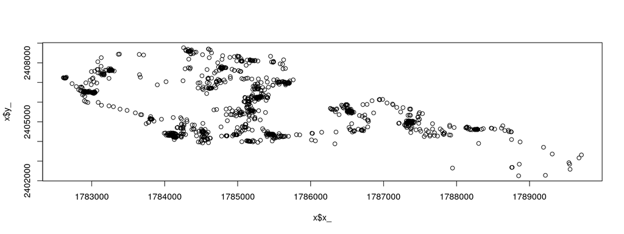

```r
plot(dat2)
```

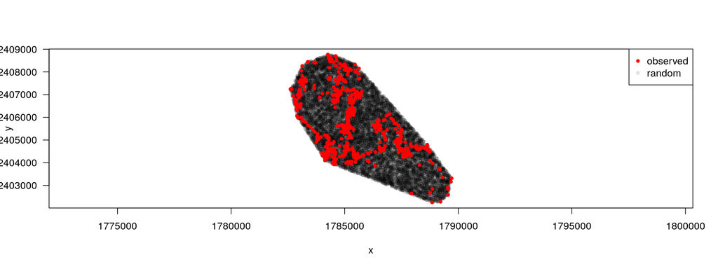

```r
plot(dat2 %>% random_points())
```

Extract covariates at random and observed points

```r
dat3 <- dat2 %>% random_points() %>% extract_covariates(env)
dat3
```

```
## # A tibble: 17,798 x 7
##    case_       x_       y_ elevation landuse pop_den forest
##    <lgl>    <dbl>    <dbl>     <dbl>   <dbl>   <dbl>  <dbl>
##  1 TRUE  1782639. 2407234.     -156.      43    453.      1
##  2 TRUE  1782637. 2407225.     -156.      43    446.      1
##  3 TRUE  1782645. 2407223.     -156.      43    446.      1
##  4 TRUE  1782627. 2407232.     -156.      43    453.      1
##  5 TRUE  1782612. 2407244.     -155.      43    458.      1
##  6 TRUE  1782634. 2407233.     -156.      43    453.      1
##  7 TRUE  1782653. 2407269.     -154.      41    456.      1
##  8 TRUE  1782639. 2407234.     -156.      43    453.      1
##  9 TRUE  1782635. 2407217.     -156.      43    446.      1
## 10 TRUE  1782629. 2407225.     -156.      43    446.      1
## # … with 17,788 more rows
```

Fit an RSF

```r
m1 <- dat3 %>% mutate(weights = if_else(case_, 1, 1000)) %>%
  glm(case_ ~ elevation + pop_den + forest, weights = weights, data = ., family = binomial())
summary(m1)
```

```
##
## Call:
## glm(formula = case_ ~ elevation + pop_den + forest, family = binomial(),
##     data = ., weights = weights)
##
## Deviance Residuals:
##     Min       1Q   Median       3Q      Max
## -0.7992  -0.5197  -0.3647  -0.3148   4.5027
##
## Coefficients:
##               Estimate Std. Error z value Pr(>|z|)
## (Intercept) -8.4592514  0.3233372 -26.162   <2e-16 ***
## elevation    0.0021002  0.0015700   1.338    0.181
## pop_den     -0.0014288  0.0001475  -9.686   <2e-16 ***
## forest       1.0237671  0.0523863  19.543   <2e-16 ***
## ---
## Signif. codes:  0 '***' 0.001 '**' 0.01 '*' 0.05 '.' 0.1 ' ' 1
##
## (Dispersion parameter for binomial family taken to be 1)
##
##     Null deviance: 33041  on 17797  degrees of freedom
## Residual deviance: 32441  on 17794  degrees of freedom
## AIC: 32449
##
## Number of Fisher Scoring iterations: 6
```

How many random points should we use? We will repeat the what we did before, but vary the number of random points. The function `random_points()` lets us specify the number of random points as a factor of the number of observed points. We will try `0.5, 1, 2, 5, 10, 20`-times as many random points as observed points. To get a sense for the variability, we will also replicate each fraction 10 times.

```r
# Note: this may take a 2-3 mins to compute
tictoc::tic()
dat_np <- tibble(factor = rep(c(0.5, 1, 2, 5, 10, 20), each = 10))
dat_np <- dat_np %>% mutate(rsf_res = map(factor, ~ {
  dat2 %>% random_points(factor = .x) %>% extract_covariates(env) %>%
    mutate(weights = if_else(case_, 1, 1000)) %>%
    glm(case_ ~ elevation + pop_den + forest, weights = weights, data = ., family = binomial()) %>%
    broom::tidy()
}))
tictoc::toc()
```

```
## 102.511 sec elapsed
```

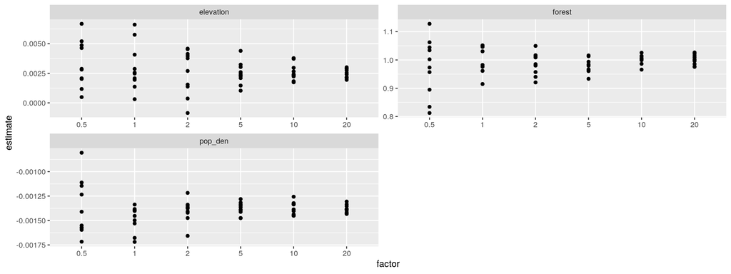

```r
dat_np %>% unnest(cols = rsf_res) %>%
  filter(term != "(Intercept)") %>% # we are not interested in the intercept
  mutate(factor = as.factor(factor)) %>%
  ggplot(aes(x = factor, y = estimate)) + geom_point() +
  facet_wrap(~ term, scales = "free", ncol = 2)
```

# Fitting Step Selection Functions (SSF)

```r
env <- read_rds(here::here("data/env_covar.rds"))
trk <- read_rds(here::here("data/trk.rds"))
```

Filter for one animal

```r
dat1 <- trk %>% filter(id == "M2")
dat2 <- track_resample(dat1, rate = minutes(10), tolerance = minutes(1))

dat3 <- dat2 %>% steps_by_burst() %>% random_steps() %>% extract_covariates(env)
```

Fit an SSF (this is just wrapper around `survival::clogit`)

```r
m1 <- dat3 %>% fit_ssf(case_ ~ elevation + pop_den + forest + strata(step_id_))
summary(m1)
```

```
## Call:
## coxph(formula = Surv(rep(1, 14113L), case_) ~ elevation + pop_den +
##     forest + strata(step_id_), data = data, method = "exact")
##
##   n= 14113, number of events= 1283
##
##                 coef  exp(coef)   se(coef)      z Pr(>|z|)
## elevation  0.0240132  1.0243039  0.0071001  3.382 0.000719 ***
## pop_den   -0.0024442  0.9975588  0.0008907 -2.744 0.006066 **
## forest     0.3829733  1.4666389  0.0896173  4.273 1.92e-05 ***
## ---
## Signif. codes:  0 '***' 0.001 '**' 0.01 '*' 0.05 '.' 0.1 ' ' 1
##
##           exp(coef) exp(-coef) lower .95 upper .95
## elevation    1.0243     0.9763    1.0101    1.0387
## pop_den      0.9976     1.0024    0.9958    0.9993
## forest       1.4666     0.6818    1.2304    1.7483
##
## Concordance= 0.55  (se = 0.009 )
## Likelihood ratio test= 48.45  on 3 df,   p=2e-10
## Wald test            = 46.11  on 3 df,   p=5e-10
## Score (logrank) test = 46.03  on 3 df,   p=6e-10
```

# Dealing with multiple animals

```r
env <- read_rds(here::here("data/env_covar.rds"))
trk <- read_rds(here::here("data/trk.rds"))

summarize_sampling_rate_many(trk, "id")
```

```
## # A tibble: 8 x 10
##   id    min       q1      median  mean    q3      max        sd     n unit
##   <fct> <table>   <table> <table> <table> <table> <table> <dbl> <int> <chr>
## 1 M1    13.26666… 14.733… 15.033… 32.745… 15.450…  976.7… 104.    918 min
## 2 M4     0.09996…  1.933…  2.033…  8.041…  2.566… 1208.5…  44.0  8957 min
## 3 F2     0.40000…  1.966…  2.033…  8.930…  3.983… 1079.9…  48.1  3003 min
## 4 M3     0.41666…  1.966…  2.166… 13.252…  5.416… 2888.6…  90.2  2435 min
## 5 F3     0.41661…  1.966…  2.066… 15.678…  4.083… 2167.4… 104.   1500 min
## 6 M2     1.34998…  9.783… 10.016… 21.729… 10.333… 2110.8…  87.2  1637 min
## 7 F1     3.91666…  9.799… 10.016… 20.693… 10.299… 1650.3…  95.2  1348 min
## 8 M5     0.24995…  1.933…  2.016…  7.408…  2.366…  976.3…  25.0 13098 min
```

```r
dat1 <- trk %>% nest(data = -id)
# This is a temporary fix
class(dat1) <- c("tbl_df", "tbl", "data.frame")
dat1
```

```
## # A tibble: 8 x 2
##   id              data
##   <fct> <list<df[,4]>>
## 1 M1         [919 × 4]
## 2 M4       [8,958 × 4]
## 3 F2       [3,004 × 4]
## 4 M3       [2,436 × 4]
## 5 F3       [1,501 × 4]
## 6 M2       [1,638 × 4]
## 7 F1       [1,349 × 4]
## 8 M5      [13,099 × 4]
```

We now repeat the same steps as before. Just that this time we have to loop over each animal. There are several ways how to achieve this. We use the `map` funciton (which is equivalent to the `lappaly` function).

```r
dat2 <- dat1 %>%
  mutate(dat_resample = map(data, ~ track_resample(., rate = minutes(30), tolerance = minutes(2))))
dat2
```

```
## # A tibble: 8 x 3
##   id              data dat_resample
##   <fct> <list<df[,4]>> <list>
## 1 M1         [919 × 4] <tibble [484 × 5]>
## 2 M4       [8,958 × 4] <tibble [1,240 × 5]>
## 3 F2       [3,004 × 4] <tibble [424 × 5]>
## 4 M3       [2,436 × 4] <tibble [357 × 5]>
## 5 F3       [1,501 × 4] <tibble [197 × 5]>
## 6 M2       [1,638 × 4] <tibble [601 × 5]>
## 7 F1       [1,349 × 4] <tibble [473 × 5]>
## 8 M5      [13,099 × 4] <tibble [1,984 × 5]>
```

Now fit for each animal a RSF

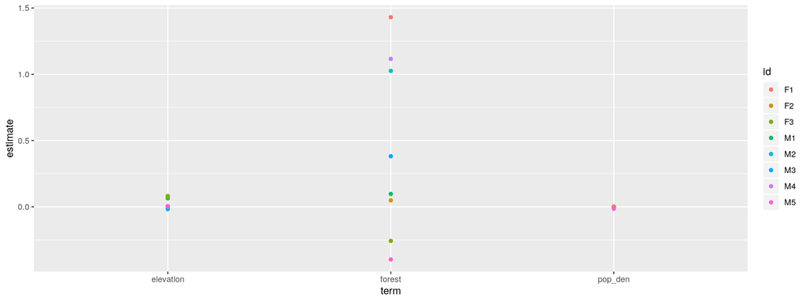

```r
dat2 <- dat2 %>%
  mutate(rsf = map(dat_resample, ~ .x %>% random_points %>% extract_covariates(env) %>%
                     fit_rsf(case_ ~ elevation + pop_den + forest)))
dat2 %>% mutate(rsf = map(rsf, ~ broom::tidy(.$model))) %>%
  unnest(cols = rsf) %>%
  filter(term != "(Intercept)") %>%
  ggplot(aes(term, estimate, col = id)) + geom_point()
```